# Bonus — Flashback on Operating Systems

Hans-Martin von Gaudecker, Gregor Böhl

# A bit of Operating System History

- At special request of former students
- Two broad sets: Unix-based/inspired (Linux, MacOS X) and Windows.

[figure not shown]

- Unix was developed at Bell labs starting 1969 (some [history](https://arstechnica.com/gadgets/2019/08/unix-at-50-it-starts-with-a-mainframe-a-gator-and-three-dedicated-researchers)), quickly evolved to become the main OS for servers.

# Unix-inspired

- Licensed to many companies for free as Bell labs (a subsidiary of AT&T) could not charge anything because of AT&T's telecommunications monopoly.
- The monopoly was broken up in the early 1980s and Unix became a commercial product.
- Early spin-offs: Berkeley Software Distribution (BSD) and GNU's Not Unix (GNU, only utilities, not the kernel itself).
- In 1991, Linus Torvalds wrote a new kernel inspired by the Unix kernel from scratch — Linux.

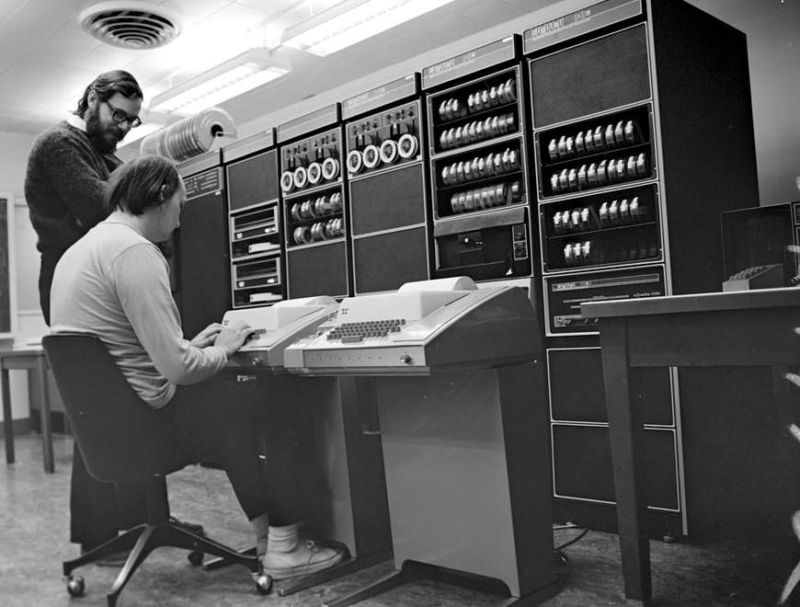

# Unix-inspired

- Many flavours of Linux today: Debian, Ubuntu, Red Hat, Mint, Android, ...
- After parting ways with Apple in the 1980s, Steve Jobs founded a company called NeXT.
- Developed the OS NeXTSTEP, which was based partly on the BSD.
- NeXT was bought by Apple in 1997, which brought back Jobs as CEO.
- macOS X, iOS, ... all based on NeXTSTEP and thus BSD, Unix.
- The Portable Operating System Interface (POSIX) aims to establish a standard for Unix derivatives.

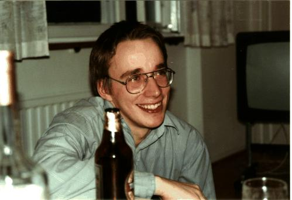

# Windows

- With a couple of exceptions, completely separate from Unix world.
- Complex history of corporate collaborations between Microsoft / IBM.
- Big break between MS-DOS / Windows 9x and Windows NT, XP, subsequent versions.

[figure not shown]

- The standard Windows command shell still looks like what I remember MS-DOS to look like in the early 1990s...
- Some convergence as of late: Windows 10 includes the [Windows Subsystem for Linux (WSL)](https://docs.microsoft.com/en-us/windows/wsl)